# Assignment2 (CellChat) Report

## 2.2 Interaction heatmaps

**Figure CC-3** – Number vs. strength of interactions

`write/figures/heatmaps_interaction_count_weight.png`

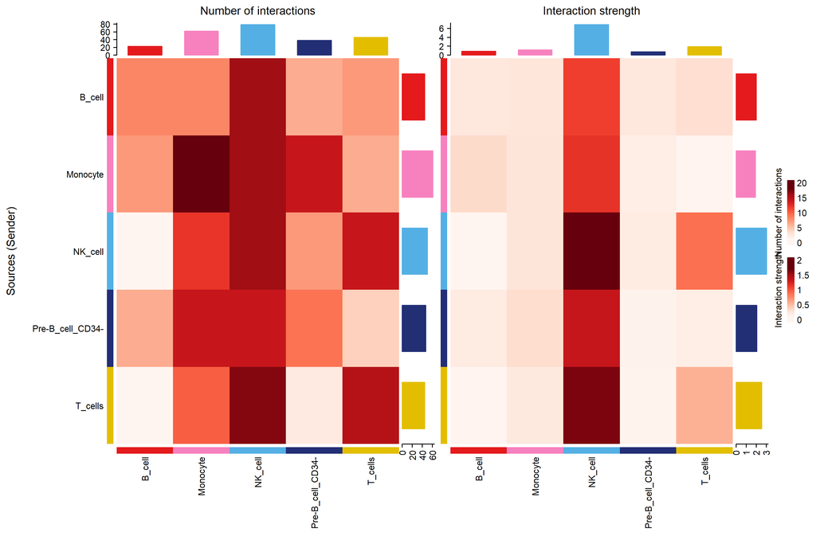

Figure CC-3 – Interaction count & weight heatmaps

## 2.3 Signalling-role scatter plot

**Figure CC-4** – Outgoing vs. incoming centrality for each cell type

`write/figures/signaling_role_scatter.png`

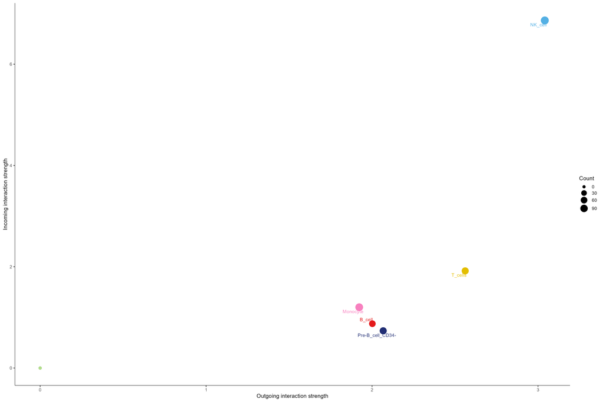

Figure CC-4 – Signalling role scatter

## 2.4 Pathway-specific views

### 2.4.1 MIF pathway

**Figure CC-5** – Circle plot (MIF pathway)

`write/figures/circle_MIF.png`

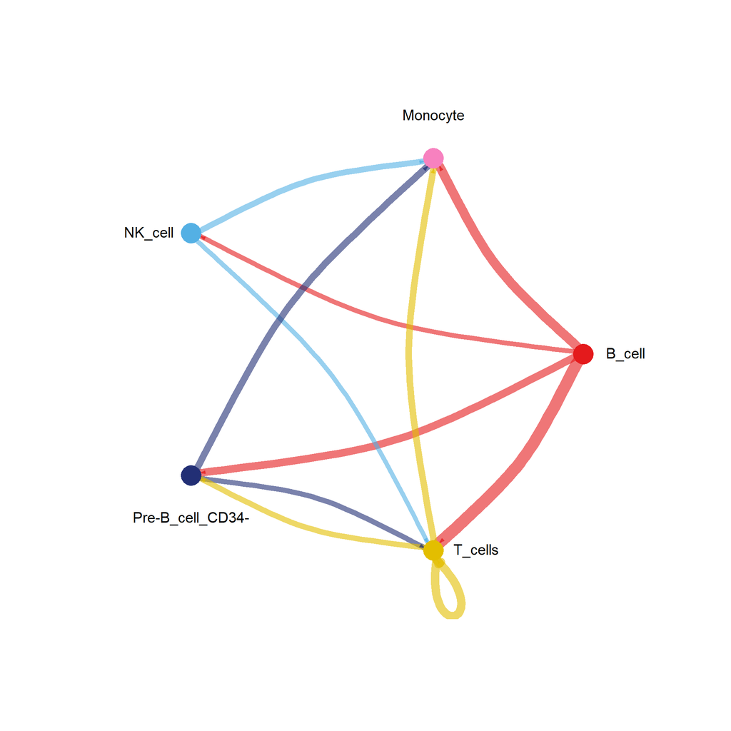

Figure CC-5 – MIF pathway circle plot

**Figure CC-6** – Bubble plot (MIF ligand-receptor pairs)

`write/figures/bubble_MIF.png`

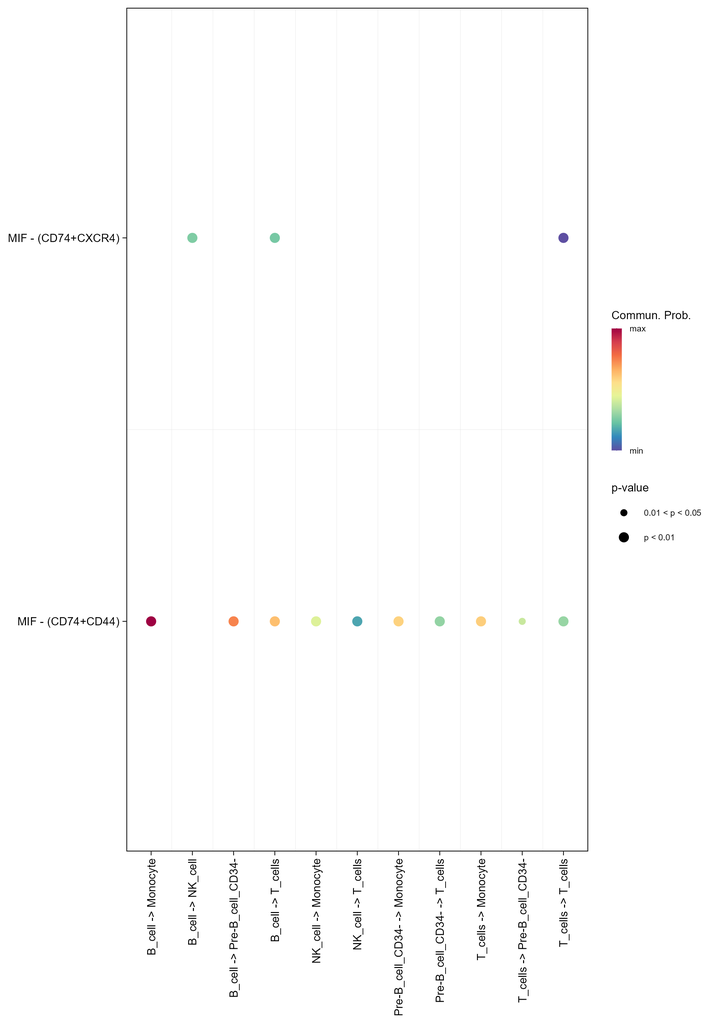

Figure CC-6 – MIF pathway bubble plot

### 2.4.2 GALECTIN pathway

**Figure CC-7** – Circle plot (GALECTIN pathway)

`write/figures/circle_GALECTIN.png`

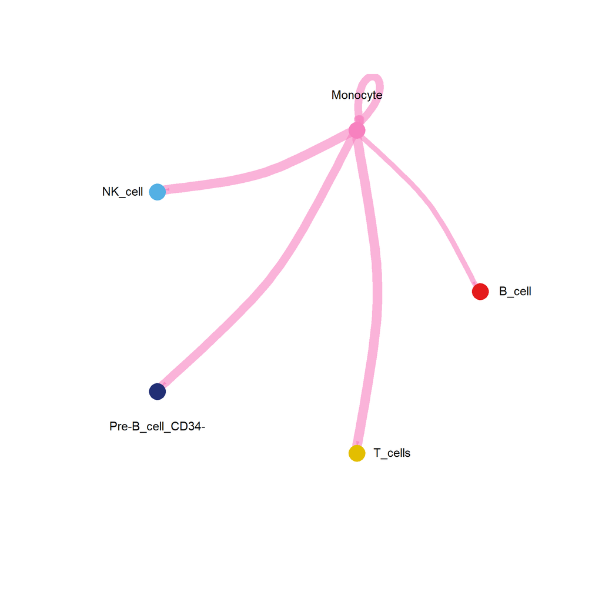

Figure CC-7 – GALECTIN pathway circle plot

**Figure CC-8** – Bubble plot (GALECTIN ligand-receptor pairs)

`write/figures/bubble_GALECTIN.png`

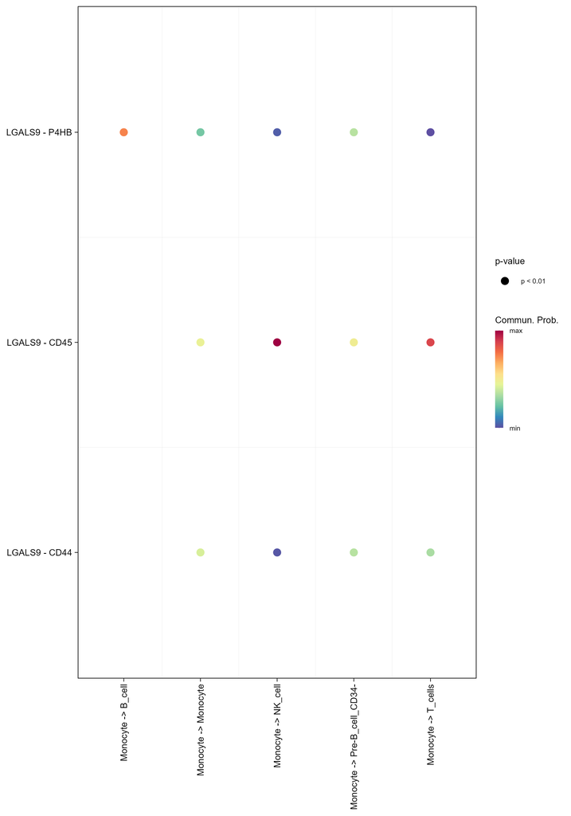

Figure CC-8 – GALECTIN pathway bubble plot